# project 1

Author

Erin Yang

# 1. Dogs Data

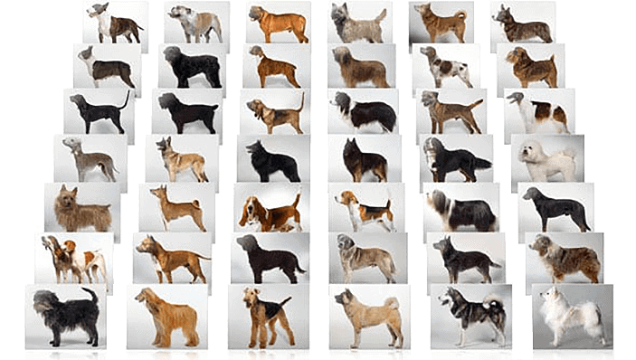

many dogs :0

```r
breed <- c('Beagle', 'Bulldog', 'Collie', 'German Shepherd', 'Golden Retriever', 'Greyhound', 'Labrador Retriever', 'Pomeranian', 'Pug', 'Shiba Inu')

avg_life <- c(12L, 9L, 13L, 9L, 11L, 12L, 11L, 14L, 14L, 15L)

energy <- factor(c('high', 'medium', 'medium', 'medium', 'very high', 'high', 'very high', 'medium', 'medium', 'medium'), levels = c('medium', 'high', 'very high'))

trainability <- c(0.6, 0.6, 0.8, 1, 1, NA, 1, 0.6, 0.6, 0.4)

friendly <- c(T, T, T, F, T, T, F, F, T, F)
```

## Subscripting

breed with the longest average life expectancy diameter:

```r
breed[which.max(avg_life)]
```

```
[1] "Shiba Inu"
```

number of unfriendly breeds:

```r
sum(friendly == F)
```

```
[1] 4
```

median trainability value of those breeds that are friendly:

```r
median(trainability[friendly == T][-5])
```

```
[1] 0.6
```

number of breeds that have average life expectancy values smaller than the median average life expectancy:

```r
length(breed[avg_life < median(avg_life)])
```

```
[1] 4
```

How many breeds have medium energy level and tend to be very friendly?

```r
length(breed[energy == 'medium' & friendly])
```

```
[1] 3
```

What breeds have medium energy level and tend to be very friendly?

```r
breed[energy == 'medium' & friendly]
```

```
[1] "Bulldog" "Collie"  "Pug"
```

What is the minimum trainability value for those breeds with an average lifetime of 13 years or more?

```r
min(trainability[avg_life >= 13])
```

```
[1] 0.4
```

# 2. Vectorized Functions

Is It Vectorized?

1. length() - no. It returns a singular number corresponding to the length of the vector.

```r
vec <- c(1, 2, 2.5, 3)
length(vec)
```

```
[1] 4
```

```r
vec * 5
```

```
[1]  5.0 10.0 12.5 15.0
```

3. log() - yes. this takes the log of every element in a vector and returns a list with all of them.

```r
log(vec)
```

```
[1] 0.0000000 0.6931472 0.9162907 1.0986123
```

4. max() - no. this compares all elements of a vector and returns the greatest one. there is only one output.

```r
max(vec)
```

```
[1] 3
```

5. trunc() - yes. this truncates the decimal values of numerical items in the vector. it then returns the full vector with truncated elements.

```r
trunc(vec)
```

```
[1] 1 2 2 3
```

# 3 Loan Amortization Payment Formula

Suppose that one of your friends recently graduated from a College in California with $45,000 in student loan debt, at an interest rate of 5.25%. What would be the monthly payment if your friend wants to pay-off their student loan in 20 years?

```r
payment <- function(p, r, n, k){
    pmt = p * (
       ((r/k) * ((1 + r/k) ** (n*k))) / (((1 + r/k) ** (n*k)) - 1)
    )
    return(pmt)
}

payment(45000, 0.0525, 20, 12)
```

```
[1] 303.2299
```

Your friend has various monthly payments to make such as rent, car loan, cell-phone, internet, streaming services, etc. With so many things to pay for, your friend is thinking of making monthly payments of $220 to pay for their student loan. How many years would it take your friend to be student-loan debt free if they plan to make monthly payments of $220? Hint: use a trial-and-error process for various values of 𝑛 to find the answer.

```r
payment(45000, 0.0525, 1:50, 12)
```

```
 [1] 3857.4941 1979.2547 1353.7472 1041.4221  854.3693  729.9519  641.3255
 [8]  575.0677  523.7215  482.8127  449.4938  421.8667  398.6170  378.8059
[15]  361.7450  346.9177  333.9290  322.4718  312.3035  303.2299  295.0938
[22]  287.7668  281.1424  275.1321  269.6615  264.6675  260.0965  255.9025
[29]  252.0456  248.4917  245.2105  242.1760  239.3650  236.7571  234.3344
[36]  232.0807  229.9817  228.0247  226.1981  224.4917  222.8959  221.4024
[43]  220.0035  218.6923  217.4624  216.3080  215.2237  214.2048  213.2468
[50]  212.3456
```

43 years.

# 4 Future Value of Ordinary Annuity

Mrs. Savingswood wants to save money for the college education of her 3 year-old daugh- ter. She plans to deposit $100 at the end of each month, for the next 15 years, into a mutual fund that gives—on average—a 10% annual rate of return. How much money will Mrs. Savingswood have at the end of 15 years?

```r
annuity <- function(PMT = 100, rate = 0.05, n_yrs = 20, comp_per = 12){ # PMT is the amount contributed every period, rate is the interest rate, n_yrs, is the number of years, and comp_per is the number of compounding periods per year
    if(rate == 0){
        fv = PMT * n_yrs * comp_per #fv is the future value
    } else{
        fv = PMT * (
            ((1 + rate/comp_per) ** (n_yrs*comp_per) - 1) /
                (rate/comp_per)
        )
    }
    return(fv)
}
```

How much money will she have after 15 years?

```r
annuity(rate = 0.1, n_yrs = 15)
```

```
[1] 41447.03
```

She will have $41447.03! Thats a lot!